# 1. Gendered Language Patterns in Professor Comments

STATS 201.2026 Sprg Project Report  
Team members: Hanyang Zhou, Raodan Zhang, Lexi Zhou  
Instructor: Prof. Markus Neumann

# 2. Research Question and Motivation

The research question of our team is: **How does gender influence students’ comment on college professors of similar teaching level in the same discipline?**

Addressing the question is significant. Specifically, we hope to extend the understanding of the social image of female and male professors in academia respectively, and hopefully mitigate any possible gender biases, while promoting a more gender equal environment and advocating for fair evaluation criteria for both genders.

In terms of a successful outcome demonstration, we expect to find some interpretable and gender-specific language patterns in comments for professors with our text processing models based on analysis on a dataset from Rate My Professor, the largest online professor commenting platform in English-speaking countries.

# 3. Data

### 3.1 Data source and provenance

We use data from RateMyProfessor (RMP), the largest online faculty rating website in the United States. RMP creates a profile for each professor, including their institution and discipline, and allows students to anonymously rate professors on a 1–5 scale and leave comments about their teaching evaluation.

Our analysis relies on a prepared open-source dataset from Mendeley Data, provided by He (2020, https://data.mendeley.com/datasets/fvtfjyvw7d/1). The dataset contains 19,685 student comments, 2,766 unique professors, 1,127 schools, and 270 disciplines, originally crawled in 2018. This dataset provides sufficient variation across fields and rating levels for modeling gendered language patterns.

### 3.2 Unit of analysis and key variables

The primary unit of analysis is the student comment.

Our research question asks: How does gender influence students’ comments on professors of similar teaching level within the same discipline?

To contexualize “similar teaching level,” we use:

- Professor star rating (Poor / Average / Good) for overall evaluation.
- Department name (we group them into STEM vs. Humanities) as a proxy for discipline.

For supervised models (Logistic Regression and Random Forest), the target variable is professor gender (male/female). The goal is to test whether language in comments systematically predicts gender, consistent across ratings and disciplines.

For the Log-Odds Ratio (LOR) analysis, there is no predictive target variable. Instead, LOR compares word patterns between two groups between female and male, and estimates which words are statistically overrepresented in each group.

The primary input features are the comment texts after preprocessing.

#### 3.4 Processing and choices

Our prepocessing includes two task: 1) identifying professors' gender and 2) text processing.

##### 3.4.1 Identifying professors' gender

First, we inferred gender from gendered pronouns appearing in comments at the comment level (male, female, conflict, unknown). Conflict cases were manually reviewed.

Second, we aggregated them to the professor level. Particularly, if non-unknown comments were consistent, we assigned a final gender label. Then, we manually coded the Professors with conflicting signals.

To resolve remaining unknown cases, we used two external resources:

- The U.S. Social Security Administration (SSA) first-name dataset.
- The Namsor gender prediction API (for unresolved names).

In the end, no professors remained manually unresolved.

##### 3.4.2 Text processing

We built a preprocessing pipeline to standardize text while preserving meaningful linguistic signals.

Steps with purposes explained:

1. Cleaning escape characters and normalizing whitespace. Lowercasing to reduce sparsity.
2. Removing punctuation. Expanding contractions (e.g., “don’t” → “do not”) to preserve negation.
3. Tokenization and lemmatization to reduce inflectional variation. Explicit negation marking within a limited scope (e.g., not helpful → NEG_helpful) to preserve sentiment structure.
4. Removing standard stopwords except negation terms (not, no, never, without), which are semantically important.
5. Removing gender pronouns to avoid mechanically encoding gender labels into text features.

These steps help us to reduce noise to better ensure that detected differences reflect broader linguistic patterns rather than trivial lexical usage.

#### 3.5 Ethical considerations

The dataset contains no student names, IP addresses, or identifiable personal information. Comments are anonymous. This reduces the privacy risks.

However, we also identify the existence of selection bias. Only students motivated to post on RMP are represented. In addition, comments may contain discriminatory language.

## 4. Problem setup

### 4.1 ML tasks

For Logistic Regression (LR) and Random Forest (RF), the task is binary text classification. Basically, we use it to predict professor gender from comment language. We prioritize interpretability, especially for LR.

For LOR, the task is to better process descriptive comparative analysis of word between gender groups.

### 4.2 Targeted variables & Inputs

- Target (LR/RF): Professor gender
- Inputs: Processed comment text (unigrams and bigrams)

### 4.3 Assumption

We acknowlegde that our research assumes that language patterns reflect underlying biases about gender.

# 5. Methods

## 5.1 Baselines

We first established simple baselines to examine the overall word distribution of the dataset and obtain preliminary evidence relevant to our research question. As a **gender-agnostic baseline**, we analyzed high-frequency tokens in student comments after standard text preprocessing. The top 20 most frequent words in the full dataset were *{'very', 'work', 'just', 'really', 'students', 'great', 'no', 'help', 'does', 'hard', 'good', 'easy', 'so', 'class', 'tests', 'teacher', 'not', 'professor', 'lot', 'best'}*, reflecting general evaluative language commonly used in teaching reviews.

We then constructed a **gender-aware baseline** using the *Difference-of-Proportions* method, computing the difference in relative token frequencies between comments about female and male professors to identify gender-leaning words. The top 20 female-leaning words: *{'helpful', 'very', 'person', 'assignments', 'work', 'sweet', 'love', 'students', 'mrs', 'help', 'shes', 'lady', 'easy', 'so', 'class', 'teacher', 'not', 'ms', 'nice', 'woman'}*; the top 20 male-leaning words: *{'boring', 'prof', 'exams', 'dr', 'great', 'interesting', 'cool', 'man', 'guy', 'good', 'material', 'final', 'mr', 'tests', 'hes', 'professor', 'lectures', 'questions', 'funny', 'best'}*. This exploratory analysis revealed systematic differences in word usage, including gendered pronouns and evaluative descriptors, indicating that gender-related signals are present in the text. However, these simple frequency-based patterns are limited, motivating the need for more advanced text processing and modeling approaches.

## 5.2 Final Models

### 5.2.1 Model 1: Random Forest + Logistic Regression

For our first modeling strategy, we use the feature importance of Random Forest and assign corresponding gender prediction directions by Logistic Regression, as Random Forest (RF) is the typical approach to extract importance words in texts for prediction, and Logistic Regression (LR) can complement the gender prediction direction with the signs of its coefficients, which is absent in RF.

Firstly, we turn the comments into TF-IDF vectors for later analysis. After splitting the train and test dataset for the six filtered datasets with both original and scrubbed comments (12 groups in total), we got 12 tables of top 20 words of most feature importance (RF) and coefficient (LR), and a sample table is shown below.

Analysis for df1_stem_poor

Scrubbed Comments – Top 20 Words

| Word | Feature Importance | Coefficient | Direction |
| --- | --- | --- | --- |
| not | 0.019870 | -1.013402 | Female |
| class | 0.013926 | 0.302380 | Male |
| test | 0.011276 | -0.956766 | Female |
| worst | 0.011043 | -1.035250 | Female |
| teach | 0.010971 | 0.725919 | Male |
| do | 0.010779 | -0.550581 | Female |
| very | 0.010292 | -0.914078 | Female |
| like | 0.009929 | -1.110122 | Female |
| terrible | 0.009430 | -0.837678 | Female |
| professor | 0.009330 | 1.040559 | Male |
| math | 0.009253 | -0.973581 | Female |
| teacher | 0.008609 | -0.098548 | Female |
| easy | 0.008516 | 0.077289 | Male |
| need | 0.007683 | -0.779691 | Female |
| just | 0.006940 | -0.184526 | Female |
| help | 0.006625 | -0.492741 | Female |
| make | 0.006543 | -0.420645 | Female |
| student | 0.006348 | -0.607278 | Female |
| recommend | 0.006274 | -0.925852 | Female |
| understand | 0.006235 | 0.276106 | Male |

In terms of tokenization, we chose **unigram + NEG_prefix** because it provided greater magnitude of feature importance and coefficients compared to the bigram.

### 5.2.2 Model 2: Log-Odds Ratio with a Dirichlet Prior

We use the Log-Odds Ratio with a Dirichlet Prior (Monroe et al., 2008) to analyze gendered language in student comments. LOR focuses on interpreting bias with statistical confidence.

#### 5.2.2.1 Procedure:

1. Count word frequencies in each gender group within each subset.
2. Apply a Dirichlet prior using a background corpus.
3. Compute log-odds ratios.
4. Estimate variance.
5. Convert to z-scores (positive = male-leaning; negative = female-leaning).

Example: Analysis for df1_stem_poor

Scrubbed Comments - Top 20 Words (with discipline terms)

| Word | Z_Score | Direction |
| --- | --- | --- |
| clinical | -2.187723 | Female |
| carson | -2.187723 | Female |
| lab | 2.172084 | Male |
| chemistry | 1.980510 | Male |
| recitation | -1.974929 | Female |
| narcisa | -1.865317 | Female |
| su | 1.768405 | Male |
| not | -1.768119 | Female |
| claire | -1.744703 | Female |
| way | -1.731438 | Female |
| time | -1.671152 | Female |
| unorganized | -1.657071 | Female |
| computer | 1.636993 | Male |
| early | -1.615131 | Female |
| smart | 1.598728 | Male |
| professor | 1.593325 | Male |
| have | -1.591786 | Female |
| review | -1.578803 | Female |
| funny | 1.546962 | Male |
| idea | 1.542612 | Male |

# 6. Evaluation & Revision

## 6.1 RF+LR

### 6.1.1 Evaluation

To evaluate the RF+LR model, we tested 20% of data and trained the model with remaining 80%. Since we have nearly 20,000 comment records and around 2500 professors, the typical split makes sense here. Later, we synthesized the heatmap of top 30 words with biggest average feature importance across six scrubbed subsets below to overview a general quantitative result of this model.

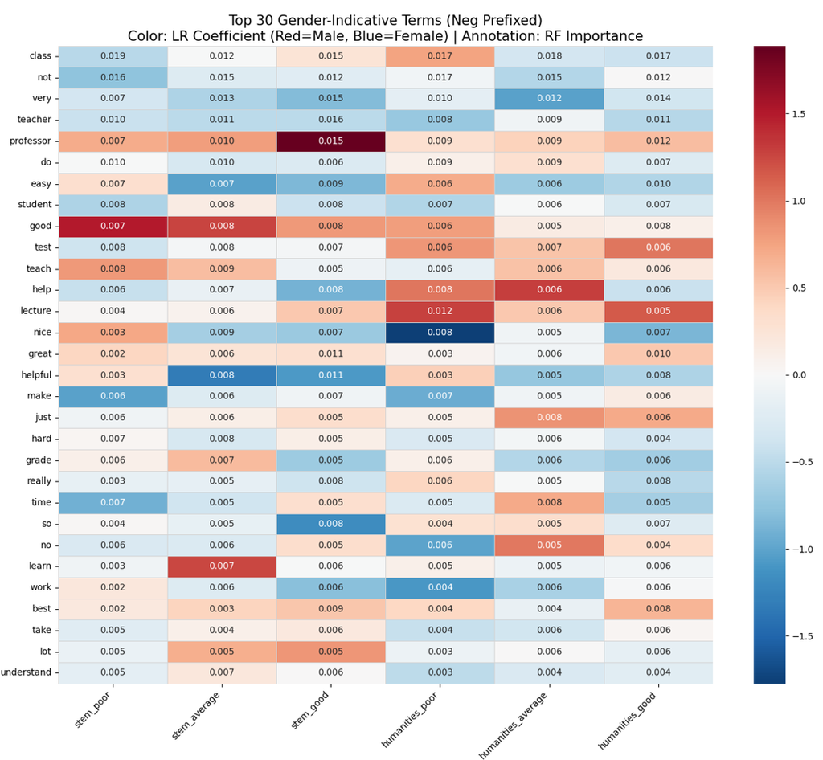

Specifically, the *digits* in each block refers to the feature importance of each words across the six subsets, and higher is their average, higher the rank. While the *color shades* stand for the magnitude of LR coefficient, referring **female in blue** and **male in red**. From the figure, no words strongly predict gender dominantly across all subsets, laying foundation for subset-level interpretations. However, some primary gendered languages are observed: **“professor”, “good”, “lecture”, “best”** are generally more predictive of comments for **male** professors; while **“teacher”, “nice”** are more for **female** professors.

### 6.1.2 Revision: 'english' stopwords

However, because too many meaningless words, such as “not”, “no”, “do”, “just”, “so” are of high feature importance, which greatly decreases the outcome **interpretability**, we chose to apply **‘english’ stopwords** to mitigate the effect.

## 6.2 LOR

### 6.2.1 Evaluation

We use semantic validity to evaluate the performance of the LOR model. Basically, we examine if the listed words show contextual meanings. This is because by using Z-scores, we stop very common words from dominating our lists.

Take the heatmap as the synthesized result to examine: among the thirty terms, sixteen are academic related, such as “math” and “slides”, six are personality related, such as “sweet” and “helpful”, and only eight terms do not have close relation to the academic context, such as “draw” and “hike.” Overall, this suggests that LOR has a sensitivity to the meaningful words in contexts.

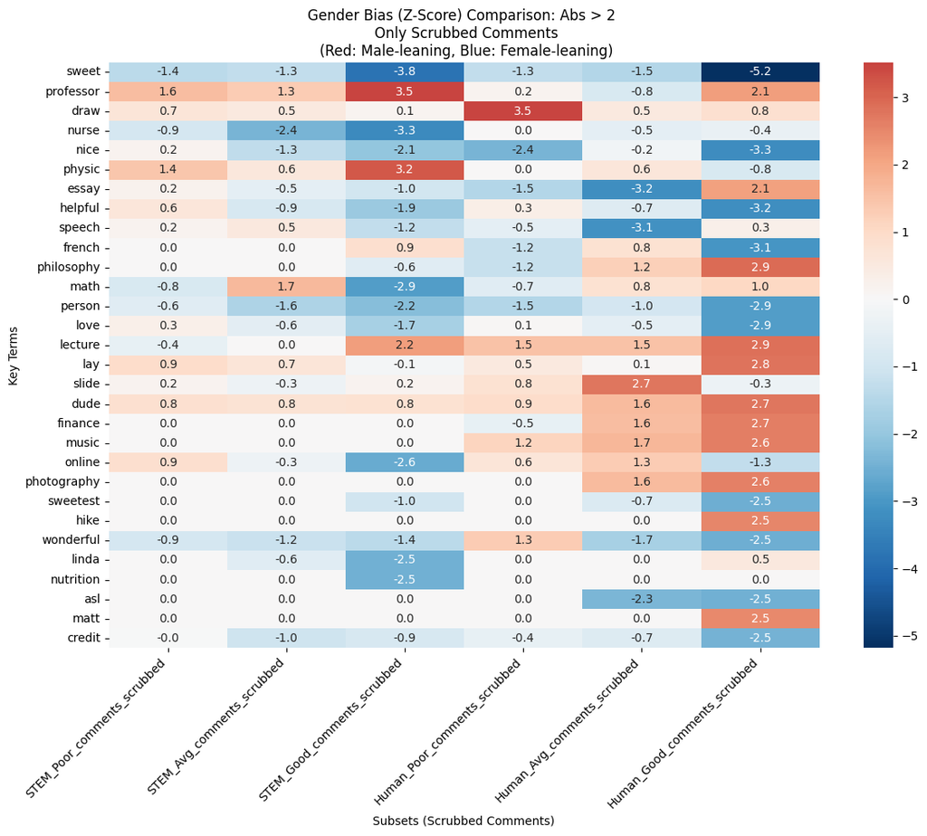

### 6.2.2 Revision: remove discipline specific terms

Initial results contained discipline nouns that reflected department distribution rather than student perception. Thus, werevised the model through a systematic filtering process: Collected all unique department names, broke into individual tokens, manual review (keep general academic terms), finally applied the blacklist to the comment_scrubbed column and finalize the comment column.

In this way, we improve the relevance of our output to our research objective.

# 7. Diagnostics

## 7.1 RF+LR

### 7.1.1 Performance Metrics

| dataset | model | accuracy | f1_score | roc_auc |
| --- | --- | --- | --- | --- |
| stem_poor | RandomForest | 0.59 | 0.70 | 0.58 |
| stem_poor | LogisticRegression | 0.60 | 0.72 | 0.66 |
| stem_average | RandomForest | 0.57 | 0.65 | 0.57 |
| stem_average | LogisticRegression | 0.56 | 0.64 | 0.59 |
| stem_good | RandomForest | 0.63 | 0.70 | 0.66 |
| stem_good | LogisticRegression | 0.64 | 0.70 | 0.69 |
| humanities_poor | RandomForest | 0.62 | 0.37 | 0.68 |
| humanities_poor | LogisticRegression | 0.64 | 0.41 | 0.69 |
| humanities_average | RandomForest | 0.62 | 0.47 | 0.65 |
| humanities_average | LogisticRegression | 0.64 | 0.52 | 0.67 |
| humanities_good | RandomForest | 0.61 | 0.62 | 0.64 |
| humanities_good | LogisticRegression | 0.61 | 0.63 | 0.67 |

### 7.1.2 Hyperparameter Tuning and Confusion Matrix Diagnostics

To assess robustness and diagnose errors, we examined confusion matrices and conducted hyperparameter tuning using **GridSearchCV**. Across subsets, confusion matrices consistently revealed asymmetric error patterns, with one gender class being predicted more accurately than the other. After tuning, performance divergence between RF and LR increased within the same data subsets, accompanied by declines in accuracy and ROC-AUC. These results indicate that the tuned pipeline became more sensitive to data variation and less robust overall. Based on these diagnostic findings, hyperparameter tuning via GridSearchCV was ultimately not adopted in the final RF+LR models.

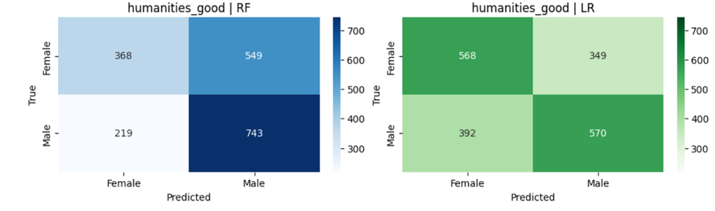

## 7.2 LOR

### 7.2.1 Dirichlet Prior Sensitivity Check

To evaluate robustness, we revised the LOR framework to allow configurable Dirichlet priors and smoothing parameter α, enabling explicit prior sensitivity checks. We compared results obtained using a background prior derived from the full dataset with flat priors that assign equal probability to all tokens. Across preprocessing strategies, the top gender-leaning words showed high consistency: 13 of the top 20 words overlapped across prior settings, and key descriptors such as *“sweet,” “nice,”* and *“helpful”* appeared persistently. This stability indicates that the LOR results are not driven by prior specification.

### 7.2.2 Frequency-Weight Plot

We further assessed model behavior using **frequency-weight plots**, which relate token frequency to standardized log-odds (z-scores). Rare words exhibited z-scores close to zero, indicating effective Bayesian shrinkage and reduced sensitivity to noise, while the most informative gender-associated terms clustered in the mid-frequency range. Although some high-frequency tokens appeared as outliers, their gender direction was consistent with heatmap results across subsets. These diagnostics suggest that the LOR framework reliably captures meaningful lexical differences without being dominated by extremely common or rare terms.

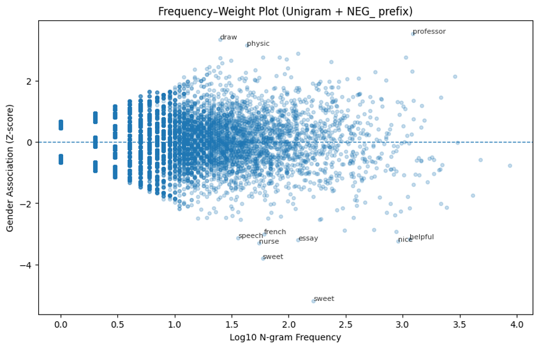

# 8. Interpretation and Substantive Takeaways

## 8.1 RF+LR

Across all subsets with unigram processing, “teacher” indicates female professors, while “professor” predicts male professors. Obviously, teacher is the title inferior to professor. The reference difference is also prominent in bigram processing, where female professors are also frequently referred to as “person” (e.g., nice person) besides “teacher”. Although some exemptions exist, such as in Poor-rated humanities, female professors were also referred as “worst professor”, the general title reference difference is alert to us and imply an underestimation of female professor’s authority. Another big difference is the expectations of personality traits for female and male professors. While affective words are generally more predictable to female professors, male professors are uniquely expected to be funny, especially in humanities.

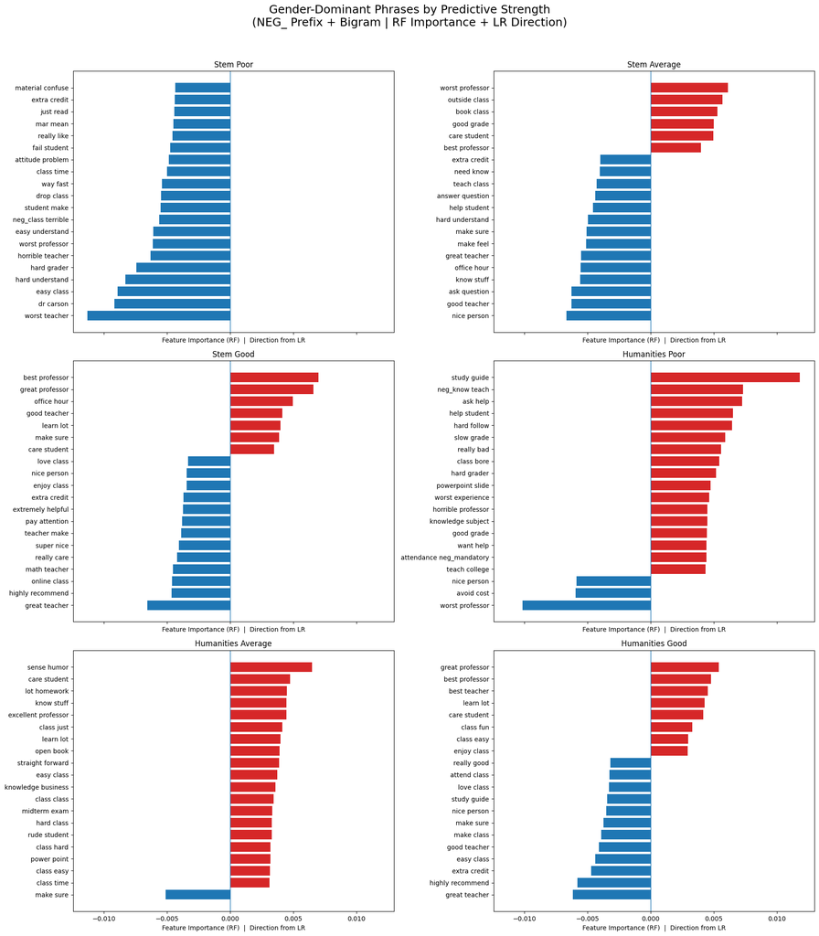

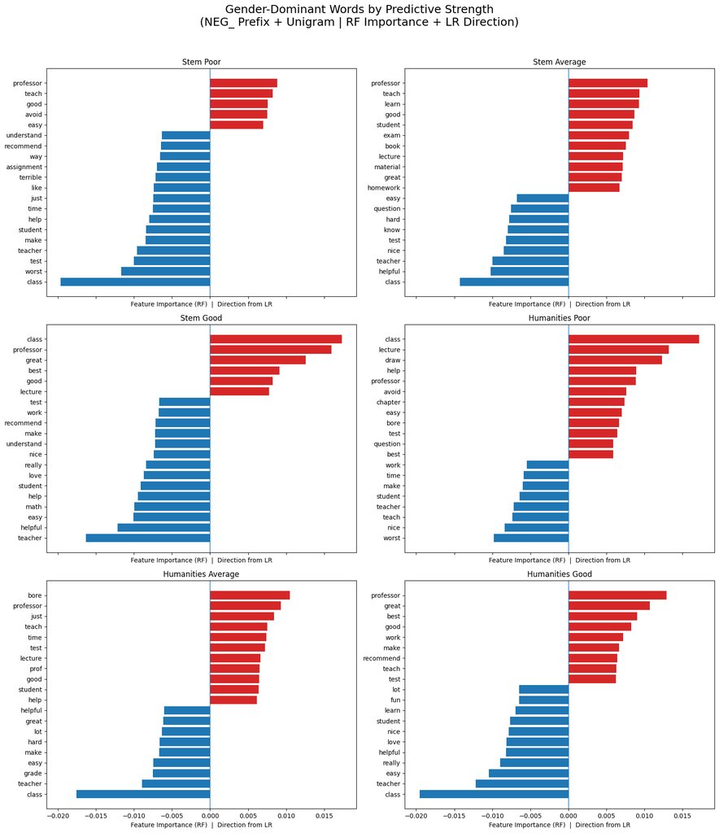

## 8.2 LOR

By combining the unigram and bigram analyses, our research suggests two consistent language patterns of professor evaluation by gender. Comments about female professors focus more on personality. Positive words include *nice, sweet, and helpful*, while negative terms such as *unorganized and strict* also center on personal characteristics.

Comments about male professors emphasize competence and performance. Words like *professor* and *smart*, as well as phrases such as *very funny* and *learn a lot*, appear more frequently.

Across disciplines, the pattern remains similar. Light differences appear across disciplines. See the charts below, in Humanities, personality-related terms are more prominent. In STEM, competence-related terms are more visible, especially for male professors.

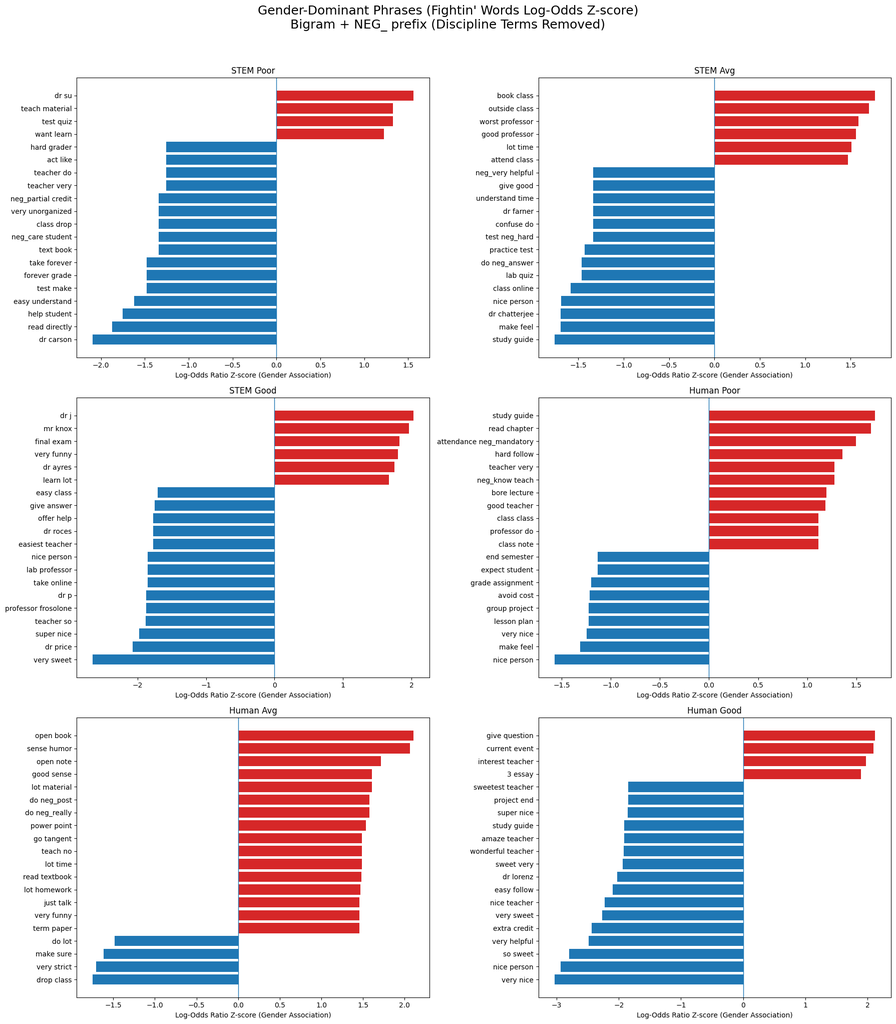

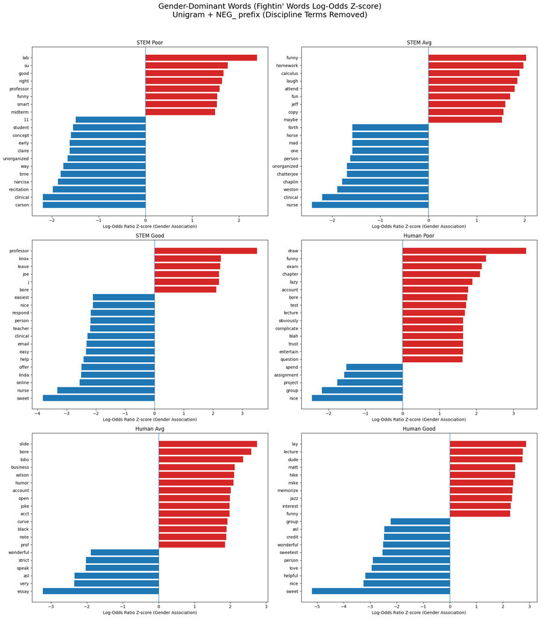

## 8.3 Main takeaways

Firstly, more subjective evaluation words and the emotion-related expectations on **female** professors may lead to their **extra emotional labor**. Secondly, being called as “teacher” or “person”, instead of “professor” as their male counterparts, indicates **female** professors’ **inferior social image**.

However, readers should be aware that these implications don’t infer causality between professor gender and the language patterns, and the words don’t reflect any gender traits backwards or predict gender biases beyond the context of our data.

# 9. Limitations and Future Work

## 9.1 Model Limitations

The **LOR** model relies on a bag-of-words representation, which cannot capture complex sentence structure or nuanced contextual meaning, even with negation prefixing. Some subtle discipline-related terms may remain after filtering, potentially introducing residual confounding. Moreover, LOR z-scores quantify statistical association rather than emotional intent or full discourse context, limiting interpretability to lexical patterns rather than deeper semantic or affective content.

## 9.2 Data Scope and Limitations

The dataset is derived from RateMyProfessor (RMP), with webpages crawled between April and July 2018, while comments may span many prior years. A major site update in 2015 resulted in missing pages, making the dataset an incomplete historical snapshot rather than a representation of current evaluations. Reviews are concentrated in U.S. universities, limiting global generalizability. In addition, RMP participation is voluntary and anonymous, introducing strong self-selection bias, and profile removals or deletions may systematically exclude certain instructors.

## 9.3 Future Work

Future work could extend this analysis by incorporating contextual NLP models (e.g., transformer-based embeddings) to better capture semantic nuance and sentence-level structure. Integrating sentiment features may help distinguish evaluative tone from topical content. Expanding to more recent and geographically diverse datasets would also improve generalizability and allow investigation of how gendered language in teaching evaluations evolves over time.

# 10. References

1. API documentation. (n.d.). Namsor | Name analysis - Instant gender, origin & ethnicity detection. https://namsor.app/api-documentation/introduction/
2. Baby Names from Social Security Card Applications—National Data. (n.d.). [Dataset]. Social Security Administration. Retrieved February 25, 2026, from https://catalog.data.gov/dataset/baby-names-from-social-security-card-applications-national-data
3. He, Jibo (2020). Big Data Set from RateMyProfessor.com for Professors' Teaching Evaluation. Mendeley Data, V1. https://doi.org/10.17632/fvtfjyvw7d.1
4. Monroe, B. L., Colaresi, M. P., & Quinn, K. M. (2008). Fightin' words: Lexical feature selection and evaluation for identifying the content of political conflict. Political Analysis, 16(4), 372-403. https://doi.org/10.1093/pan/mpn018

### Use of Generative AI Tools

Generative AI tools, including ChatGPT and Google Gemini, were used as auxiliary resources to support idea generation and assist with coding structure and debugging. All analytical decisions, model design, and result interpretation were conducted and verified by the authors. The use of these tools did not replace independent reasoning or original analysis.